# Lab_22_Polynomial_And_Interaction_Features

## What is a Polynomial Feature?

**Definition:** A **Polynomial Feature** is created by taking powers of an existing feature.

## The Hidden Pattern

Look at the marks:

| Hours | Hours² | Marks |
| --- | --- | --- |
| 1 | 1 | 10 |
| 2 | 4 | 40 |
| 3 | 9 | 90 |
| 4 | 16 | 160 |

Notice:

$$ \text{Marks} = \text{Hours}^2 \times 10 $$

The relationship is actually based on **Hours²**.

But the model cannot see **Hours²** unless we provide it.

### Understanding the Pattern

Consider the values:

**1 → 2 → 3 → 4 → 5**

The increase is constant:

**+1 +1 +1 +1**

Now suppose we create a new feature by **squaring** each value.

Then:

**1² → 2² → 3² → 4² → 5²**

which gives:

**1 → 4 → 9 → 16 → 25**

Now look at the increases:

**+3 +5 +7 +9**

## So the original feature increases at a constant rate:

**1 → 2 → 3 → 4 → 5**

**+1 +1 +1 +1**

## while the squared feature increases at an increasing rate:

**1 → 4 → 9 → 16 → 25**

**+3 +5 +7 +9**

This is the **key intuition**:

> **Squaring transforms the original feature and introduces a non-linear pattern into its values.**

```python
import pandas as pd
import matplotlib.pyplot as plt

df = pd.DataFrame({
    "Hours_Studied": [1, 2, 3, 4, 5, 6, 7, 8],
    "Marks": [12, 18, 28, 40, 55, 72, 91, 112]
})

df
```

|  | Hours_Studied | Marks |
| --- | --- | --- |
| 0 | 1 | 12 |
| 1 | 2 | 18 |
| 2 | 3 | 28 |
| 3 | 4 | 40 |
| 4 | 5 | 55 |
| 5 | 6 | 72 |
| 6 | 7 | 91 |
| 7 | 8 | 112 |

### Look at the original relationship

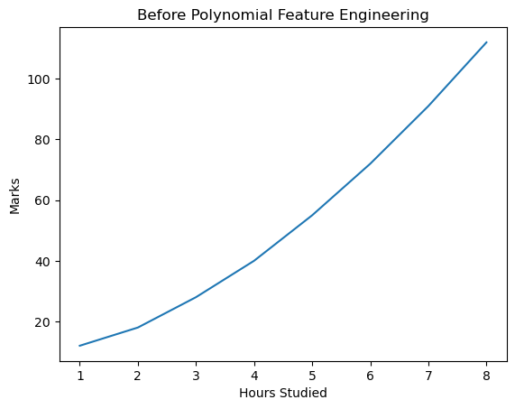

```python
plt.plot(df["Hours_Studied"], df["Marks"])

plt.xlabel("Hours Studied")
plt.ylabel("Marks")
plt.title("Before Polynomial Feature Engineering")

plt.show()
```

```python
df["Hours_Squared"] = df["Hours_Studied"] ** 2
df
```

|  | Hours_Studied | Marks | Hours_Squared |
| --- | --- | --- | --- |
| 0 | 1 | 12 | 1 |
| 1 | 2 | 18 | 4 |
| 2 | 3 | 28 | 9 |
| 3 | 4 | 40 | 16 |
| 4 | 5 | 55 | 25 |
| 5 | 6 | 72 | 36 |
| 6 | 7 | 91 | 49 |
| 7 | 8 | 112 | 64 |

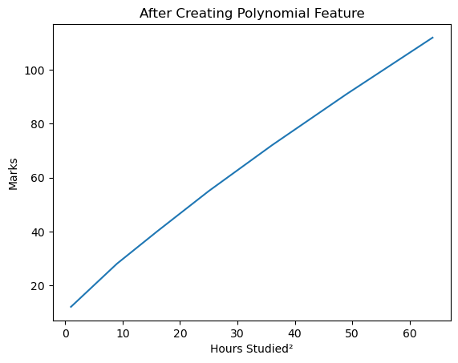

```python
plt.plot(df["Hours_Squared"], df["Marks"])

plt.xlabel("Hours Studied²")
plt.ylabel("Marks")
plt.title("After Creating Polynomial Feature")

plt.show()
```

This figure demonstrates the **idea behind Polynomial Feature Engineering**.

### 1. Before Creating a Polynomial Feature

In the first graph, we consider:

**Hours Studied → Marks**

As the number of hours increases, the marks also increase. However, the increase is **not constant**.

The relationship forms a **curve rather than a straight line**.

This indicates that the relationship between the feature and the target is **non-linear**.

### 2. Creating a Polynomial Feature

To capture this non-linear relationship, we transform the original feature.

For example:

**Hours Studied → Hours²**

So, instead of using only:

> **Hours Studied**

we create an additional feature:

> **Hours Squared**

This is called a **Polynomial Feature**.

### 3. After Creating the Polynomial Feature

The second graph shows the relationship between:

**Hours² → Marks**

The relationship now appears **much closer to a straight-line relationship**.

This means that the transformed feature can represent the original non-linear relationship in a form that a linear model can handle more effectively.

### 4. The Main Concept

The important point is:

> **Polynomial feature engineering does not change the target values. It transforms the input features to help the model capture non-linear relationships.**

Conceptually:

```
Original Feature
      ↓
  Transformation
      ↓
Polynomial Feature
      ↓
Better representation of
the non-linear relationship
```

# Advertising and Sales

Suppose a company spends money on:

- **TV Advertising**
- **Social Media Advertising**

and we observe the resulting sales.

Imagine this:

| TV Advertising | Social Media Advertising | Sales |
| --- | --- | --- |
| 10 | 2 | 50 |
| 10 | 8 | 70 |
| 50 | 2 | 70 |
| 50 | 8 | 130 |

Now look carefully at what is happening.

## First Comparison

Keep TV advertising fixed at 10:

```
TV = 10

Social Media = 2  → Sales = 50
Social Media = 8  → Sales = 70
```

Increasing social-media advertising increases sales.

Fine.

Now look at the same change when TV advertising is high:

```
TV = 50

Social Media = 2  → Sales = 70
Social Media = 8  → Sales = 130
```

The increase is much larger.

# The Interesting Observation

The effect of Social Media advertising appears to depend on the level of TV advertising.

In other words:

> **Social Media advertising does not operate completely independently of TV advertising.**

And this is exactly the situation where an **interaction** can be useful.

We can create:

$$ TV \times SocialMedia $$

Let's calculate it.

| TV | Social Media | TV × Social Media |
| --- | --- | --- |
| 10 | 2 | 20 |
| 10 | 8 | 80 |
| 50 | 2 | 100 |
| 50 | 8 | 400 |

**Now we have created a new feature:**

Think about the last two cases.

### Case 1

TV = 50

Social Media = 2

50 × 2 = 100

### Case 2

TV = 50

Social Media = 8

50 × 8 = 400

The interaction value becomes much larger when both advertising channels are high.

So the new feature represents something that the individual columns don't explicitly represent:

The combined level of TV advertising and Social Media advertising.

```python
import pandas as pd

df = pd.DataFrame({
    "TV": [10, 10, 50, 50],
    "Social_Media": [2, 8, 2, 8],
    "Sales": [50, 70, 70, 130]
})

df
```

|  | TV | Social_Media | Sales |
| --- | --- | --- | --- |
| 0 | 10 | 2 | 50 |
| 1 | 10 | 8 | 70 |
| 2 | 50 | 2 | 70 |
| 3 | 50 | 8 | 130 |

```python
df["TV_Social_Interaction"] = (
    df["TV"] * df["Social_Media"]
)

df
```

|  | TV | Social_Media | Sales | TV_Social_Interaction |
| --- | --- | --- | --- | --- |
| 0 | 10 | 2 | 50 | 20 |
| 1 | 10 | 8 | 70 | 80 |
| 2 | 50 | 2 | 70 | 100 |
| 3 | 50 | 8 | 130 | 400 |